# Final Project - GEOG 533

Daniella Madubuike

December 3, 2017

### Changing Car Culture Through Carpooling

##### Description

Research focused on measuring the carpooling potential of students by estimating the overall interest and willingness of students to utilize this potential alternative transportation option.

##### Need for Analysis

To compare variables obtained from survey and find correlations and positive/negative relationships.

##### Problem

Binghamton Univeristy has a large parking problem. It also lacks student location data.

##### Results/Benefits

The tool can be incorporated into potential future carpooling systems. Could help to reduce the inherent car culture of single-occupancy driving.

##### Test Data

Survey questions based on satisfaction, drive time, comfort level with carpooling, perceived benefits, and perceived drawbacks of carpooling, were asked, in both open-ended and close-ended question format.

## Location Analysis

#### Distance Based Analysis: Average Nearest Neighbor

```r
#####Change working directory to where data below is located.
setwd("/Users/daniellamadubuike/Documents")
library(ggmap)
library(Rcpp)

if(!require(readxl)) install.packages("readxl")
library(readxl)
lats <- read_excel("excellatlonwo.xlsx")

data(lats)
```

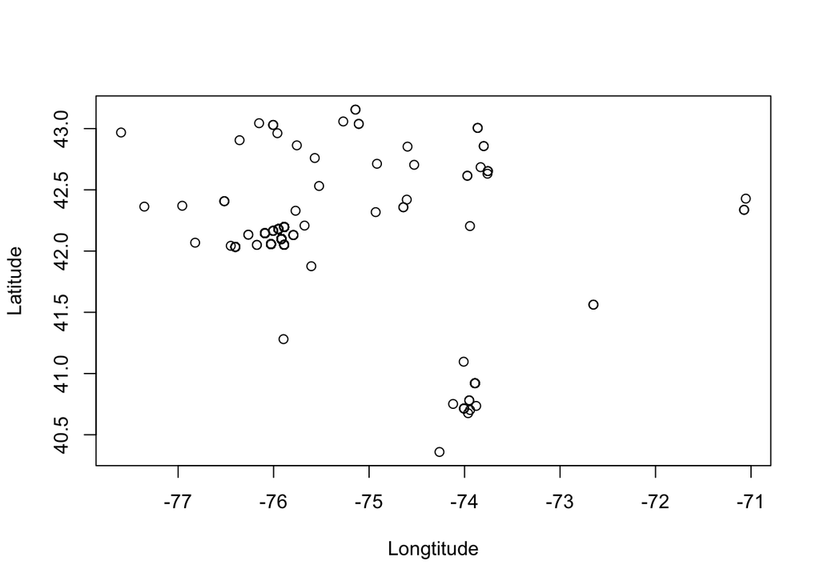

```r
plot(lats$Longitude,lats$Latitude,xlab="Longtitude",ylab="Latitude")
```

Using the ‘spatstat’ package.

```r
if(!require(spatstat)) install.packages("spatstat")
library(spatstat)
P <- lats
```

To compute the average *first* nearest neighbor distance (1st order):

```r
mean(nndist(P, k=1))
```

```
## [1] 0.01043763
```

To compute the average *second* nearest neighbor distance (2nd order):

```r
mean(nndist(P, k=2))
```

```
## [1] 0.01968601
```

To plot average distance as a function of neighbor order for the first 100 closest neighbors:

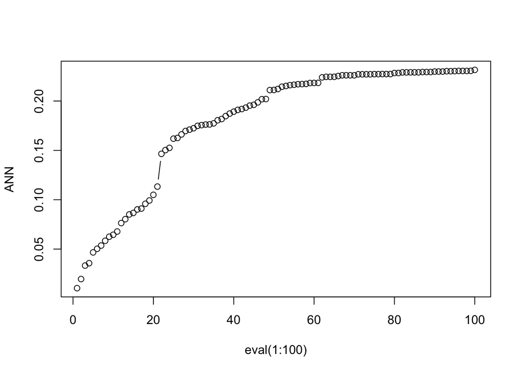

```r
ANN <- apply(nndist(P, k=1:100),2,FUN=mean)
plot(ANN ~ eval(1:100), type="b", main=NULL )
```

The bottom axis shows the neighbor order number and the left axis shows the average distance.

## Statistical Analysis

#### Categorical Data: Chi – Square Test

Public Transportation Frequency *VS* Satisfaction With Parking

Null: There is no correlation between student public transportation use frequency and their satisfaction with parking Alternative: There is a correlation between student public transportation use frequency and their satisfaction with parking

```r
if(!require(readxl)) install.packages("readxl")
library(readxl)
excel <- read_excel("excel.xlsx")
tbl = table(excel$`Public transportation Use Frequency`, excel$`Satisfaction W Parking`)
tbl
```

```
##
##                                Dissatisfied
##   More than three times a week           11
##   Never                                 231
##   Once a week                            13
##   Three times a week                      6
##   Twice a week                           14
##
##                                Neither satisfied nor dissatisfied
##   More than three times a week                                  5
##   Never                                                       103
##   Once a week                                                   7
##   Three times a week                                            7
##   Twice a week                                                 10
##
##                                Satisfied Very dissatisfied Very satisfied
##   More than three times a week         3                11              0
##   Never                               57               146              6
##   Once a week                          5                18              1
##   Three times a week                   3                 4              0
##   Twice a week                         8                 2              2
```

```r
chisq.test(tbl, simulate.p.value = TRUE)
```

```
##
##  Pearson's Chi-squared test with simulated p-value (based on 2000
##  replicates)
##
## data:  tbl
## X-squared = 27.781, df = NA, p-value = 0.04898
```

P-value is 0.04, we reject the null.

##### Continuous Data: Anova Test

Income *VS* Parking Time

Null: There is no correlation between student income and the amount of time is takes them to park. Alternative: There is a correlation between student income and the amount of time is takes them to park.

```r
if(!require(readxl)) install.packages("readxl")
library(readxl)
excel <- read_excel("excel.xlsx")

x <- excel$Income
y <- excel$`Parking Time`
plot(y ~ x)
m <- lm(y~x)
summary(m)
```

```
##
## Call:
## lm(formula = y ~ x)
##
## Residuals:
##     Min      1Q  Median      3Q     Max
## -9.6450 -4.4648  0.2555  2.9486 10.5342
##
## Coefficients:
##               Estimate Std. Error t value Pr(>|t|)
## (Intercept)  9.7497162  0.3198913  30.478   <2e-16 ***
## x           -0.0005238  0.0008526  -0.614    0.539
## ---
## Signif. codes:  0 '***' 0.001 '**' 0.01 '*' 0.05 '.' 0.1 ' ' 1
##
## Residual standard error: 4.623 on 445 degrees of freedom
##   (228 observations deleted due to missingness)
## Multiple R-squared:  0.0008475,  Adjusted R-squared:  -0.001398
## F-statistic: 0.3775 on 1 and 445 DF,  p-value: 0.5393
```

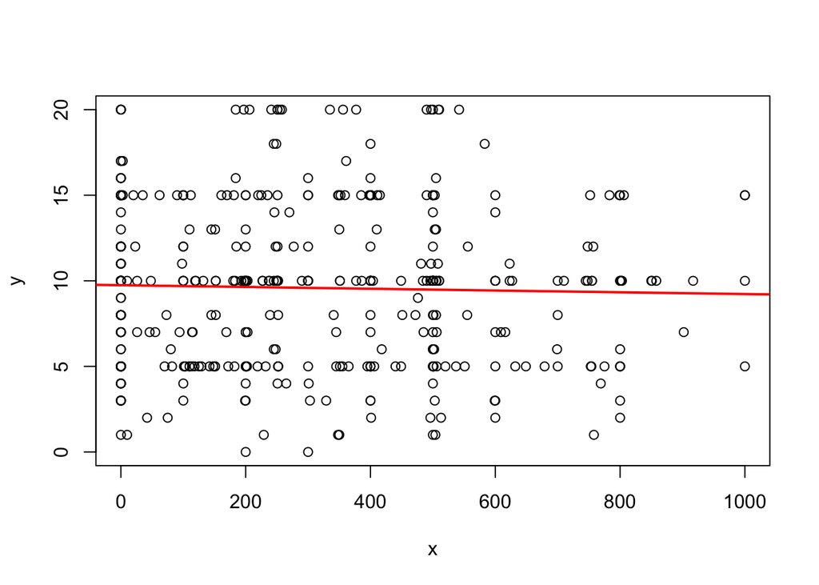

```r
abline(m,col="red",lwd=2)
```

P-value is 0.539, so we fail to reject the null.

## Qualitative Data

#### World Cloud

Data Mining

```r
if(!require(tm)) install.packages("tm")  # for text mining
```

```r
if(!require(SnowballC))install.packages("SnowballC") # for text stemming
if(!require(wordcloud))install.packages("wordcloud") # word-cloud generator
if(!require(RColorBrewer))install.packages("RColorBrewer") # color palettes

library("tm")
library("SnowballC")
library("wordcloud")
library("RColorBrewer")
```

Place data in text file and read into R, then create Corpus

```r
filepath <- "https://dmadubu1.github.io/comment.txt"
text <- readLines(filepath)
docs <- Corpus(VectorSource(text))
#inspect(docs)
```

Remove unwanted punctuation marks

```r
toSpace <- content_transformer(function (x , pattern ) gsub(pattern, " ", x))
docs <- tm_map(docs, toSpace, "/")
docs <- tm_map(docs, toSpace, "@")
docs <- tm_map(docs, toSpace, "\\|")
```

Remove other unwanted words and others

```r
# Convert the text to lower case
docs <- tm_map(docs, content_transformer(tolower))
# Remove numbers
docs <- tm_map(docs, removeNumbers)
# Remove english common stopwords
docs <- tm_map(docs, removeWords, stopwords("english"))
# Remove your own stop word
# specify your stopwords as a character vector
docs <- tm_map(docs, removeWords, c("blabla1", "blabla2"))
# Remove punctuations
docs <- tm_map(docs, removePunctuation)
# Eliminate extra white spaces
docs <- tm_map(docs, stripWhitespace)
# Text stemming
# docs <- tm_map(docs, stemDocument)
```

Sort text file

```r
dtm <- TermDocumentMatrix(docs)
m <- as.matrix(dtm)
v <- sort(rowSums(m),decreasing=TRUE)
d <- data.frame(word = names(v),freq=v)
head(d, 10)
```

```
##                  word freq
## parking       parking  180
## campus         campus   66
## people         people   37
## students     students   37
## spots           spots   33
## carpooling carpooling   29
## need             need   25
## spot             spot   25
## lot               lot   24
## make             make   24
```

Set seed and creat world cloud

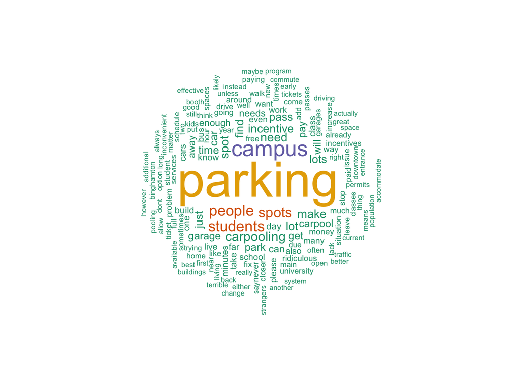

```r
set.seed(1234)
wordcloud(words = d$word, freq = d$freq, min.freq = 1,
          max.words=150, random.order=FALSE, rot.per=0.35,
          colors=brewer.pal(6, "Dark2"))
```

World cloud show trend words like parking, campus, spots, students, people, carpooling, incentive. As expected.